# Predicción del rating de Las aplicaciones en Google Play Store

Reto DataSource

[Edimer (Sidereus)](https://edimer.github.io/)

[figure not shown]

- [Sitio oficial del reto en DataSource.](https://www.datasource.ai/es/home/data-science-competitions-for-startups/prediciendo-el-rating-de-las-aplicaciones-en-google-play-store)

# Metodología

- Las siguientes imágenes fueron tomadas del libro [Tidy Modeling with R](https://xgboost.readthedocs.io/en/latest/parameter.html) de [Max Kuhn](https://github.com/topepo) y [Julia Silge.](https://github.com/juliasilge)

## Marco General

[figure not shown]

## Estrategia de Validación

- La siguiente imagen fue tomada de [tidymodels.org](https://www.tidymodels.org/start/case-study/) e ilustra la estrategia de evaluación de modelos que adopté.

[figure not shown]

## Fases del Modelado

[figure not shown]

## Libros

### *Tidy Modeling with R*

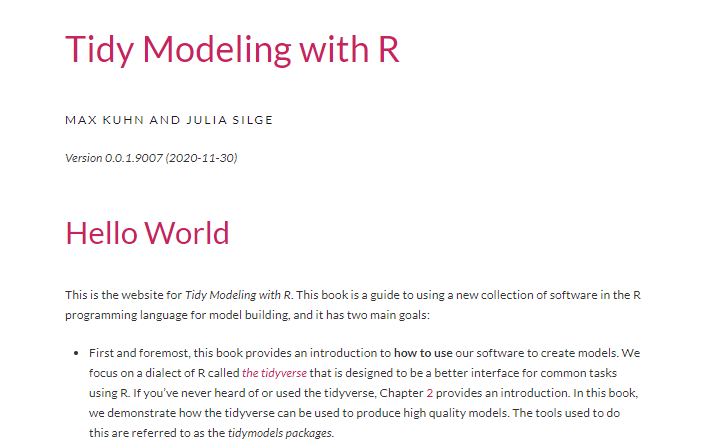

### *Applied Predictive Modeling*

- Consultar el libro [aquí.](http://appliedpredictivemodeling.com/)

[figure not shown]

### *Feature Engineering and Selection A Practical Approach for Predictive Models*

- Consultar libro [aquí.](http://www.feat.engineering/)

[figure not shown]

# Variables

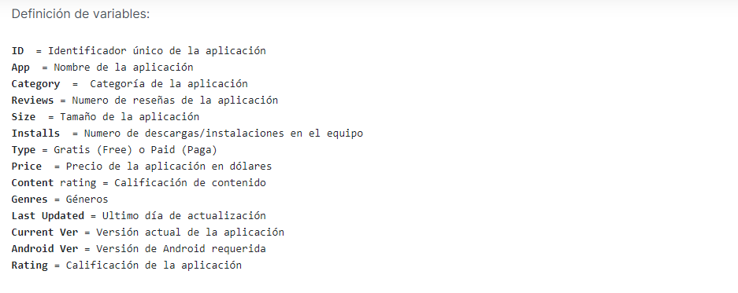

# Datos

```r
# Cargando datos
library(tidyverse)
load("../data/my_train1.Rdata")
load("../data/my_test1.Rdata")
sampleSub <- read_csv("../data/sample_submission.csv")
head(new_train1)
```

| App | Category | Rating | Reviews | Type | content_rating | new_genres | date_update | new_day | new_year | size_kb | new_installs | new_price | new_month_num | new_version | new_subversion | min_android |
| --- | --- | --- | --- | --- | --- | --- | --- | --- | --- | --- | --- | --- | --- | --- | --- | --- |
| GPS Status & Toolbox | Travel_and_local | 1 | 149723 | Free | Everyone | Travel & Local | 2018-06-13 | 13 | 2018 | 4100 | 1e+07 | 0.00 | 6 | 8 | 1 | 4.0 |
| Fish\|Hunt FL | Lifestyle | 0 | 853 | Free | Everyone | Lifestyle | 2018-03-22 | 22 | 2018 | 34000 | 1e+05 | 0.00 | 3 | 3 | 2 | 4.1 |
| Allrecipes Dinner Spinner | Food_and_drink | 1 | 61881 | Free | Everyone | Food & Drink | 2018-04-10 | 10 | 2018 | NA | 5e+06 | 0.00 | 4 | NA | NA | NA |
| Don't touch my phone | Tools | 0 | 21943 | Free | Everyone | Tools | 2016-10-19 | 19 | 2016 | 2300 | 5e+06 | 0.00 | 10 | NA | NA | 2.3 |
| BM SPM Practice | Family | 1 | 6 | Free | Everyone | Education | 2018-01-24 | 24 | 2018 | 9200 | 1e+03 | 0.00 | 1 | 1 | 0 | 4.1 |
| Advanced EX for FIAT | Tools | 0 | 138 | Paid | Everyone | Tools | 2015-03-05 | 5 | 2015 | 141 | 5e+03 | 4.99 | 3 | 1 | 6 | 1.6 |

- Selecciono sólo las variables que van a ingresar al análisis.

```r
mi_train <- new_train1 %>%
  select(-c(App, date_update))

mi_test <- new_test1 %>%
  select(-c(App, date_update))
```

- Primero se garantiza que los modelos sean entrenados con las mismas variables que contiene el archivo de test (submission).

```r
library(fastDummies)
# Binarización en test
binar_train <- dummy_cols(mi_train, remove_selected_columns = TRUE)
binar_test <- dummy_cols(mi_test, remove_selected_columns = TRUE)

# Las mismas variables en train y test (submission)
variables_iguales <- c(names(binar_train)[names(binar_train) %in% names(binar_test)],
                       "Rating")

# Datos de train finales
binar_train <- binar_train[, variables_iguales]
```

# Modelo XGBoost

- [Documentación XGBoost](https://xgboost.readthedocs.io/en/latest/)
- [Ejemplo de xgboost con tidymodels](https://www.r-bloggers.com/2020/05/using-xgboost-with-tidymodels/)
- [Ejemplo (youtube) de xgboost con tidymodels](https://www.youtube.com/watch?v=hpudxAmxHSM&ab_channel=JuliaSilge)
- En este caso no voy a imputar datos ya que este algoritmo soporta y maneja valores ausentes.
- Preprocesamiento:
  - Binarización (previamente binarizadas). Este paso se podría obviar porque el algoritmo tiene la capacidad de definir la mejor estrategia de codificación para variables categóricas.
  - Como es un problema de clasificación imbalanceado, utilizo la biblioteca themis para generar clases balanceadas a través de muestreo con reemplazo.
- Pasos a seguir con *tidymodels*:
  - 0. División en *train*, *validación* y *test*
  - 1. Definir preprocesamiento
  - 2. Definir el modelo y los hiperparámetros a optimizar
  - 3. Definir la estrategia de validación del modelo
  - 4. Definir tipo de *tuning* (grid de hiperparámetros)
  - 5. Definir el frujo de trabajo (*workflow* en *tidymodels*)
  - 6. Ejecución o entrenamiento de modelos (*tuning*)
  - 7. Evaluación de modelos (gráficos con métricas de error)
  - 8. Ajuste del modelo final
  - 9. Predicciones finales

# Etapas del modelo

## Etapa 0 - Split

```r
# Preprocesamiento
library(themis)
library(tidymodels)

# Train-Test
set.seed(2020)
data_split <- initial_split(data = binar_train, prop = 0.80)
data_train <- training(data_split) %>% mutate(Rating = as.factor(Rating))
data_test <- testing(data_split) %>% mutate(Rating = as.factor(Rating))
```

## Etapa 1 - Preprocesamiento

```r
# Receta
receta1 <- recipe(Rating ~ ., data = data_train) %>%
  step_upsample(Rating) %>%
  prep()

# Data preprocesada
data_train_fin <- bake(receta1,
                       new_data = data_train)
```

## Etapa 2 - Modelo XGBoost

- [Hiperparámetros del modelo XGBoost](https://xgboost.readthedocs.io/en/latest/parameter.html)

```r
library(xgboost)
modelo_xgb <- boost_tree(
  mode = "classification",
  trees = 5000,
  mtry = tune(),
  min_n = tune(),
  tree_depth = tune(),
  learn_rate = 0.01,
  loss_reduction = tune(),
  sample_size = tune()
) %>%
  set_engine("xgboost")
```

## Etapa 3 - Validación

```r
set.seed(1234)
cv_config <- vfold_cv(data = data_train_fin,
                      v = 10,
                      strata = Rating)
```

## Etapa 4 - Grid Tuning

- En este caso voy a usar máxima entropia de tamaño 100

```r
set.seed(12345)
# Hiperparámetros
xgboost_params <- parameters(finalize(mtry(), x = data_train_fin[, -1]),
                             min_n(),
                             tree_depth(),
                             loss_reduction(),
                             sample_size = sample_prop())

# Grid
xgboost_grid <- grid_max_entropy(xgboost_params,
                                 size = 100)
```

## Etapa 5 - *Workflow*

```r
xgboost_wf <- workflow() %>%
  add_model(modelo_xgb) %>%
  add_formula(Rating ~ .)
```

## Etapa 6 - *Tuning*

- Tiempo aproximado de ejecución: 8.5 horas.

```r
# Tiempos
library(tictoc)
tic() # Tiempo 0

doParallel::registerDoParallel() # Inicio Paralelización

# Tuning
xgboost_tuned <- tune_grid(
  object = xgboost_wf,
  resamples = cv_config,
  grid = xgboost_grid,
  metrics = metric_set(accuracy, f_meas, roc_auc),
  control = control_grid(verbose = TRUE, save_pred = TRUE)
)

doParallel::stopImplicitCluster() # Fin Paralelización

toc() # Tiempo final
```

```
29738.94 sec elapsed
```

## Etapa 7 - Evaluación de modelos

- Se obtiene como resultado una tabla con 300 observaciones (filas). 100 por cada métrica de error.

### Accuracy

- **Hiperparámetros Individuales:**

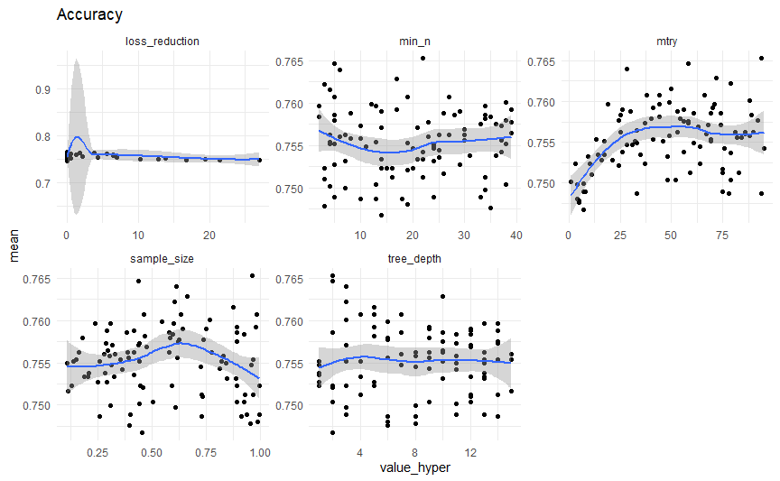

- `mtry`, `min_n` y `tree_depth`:

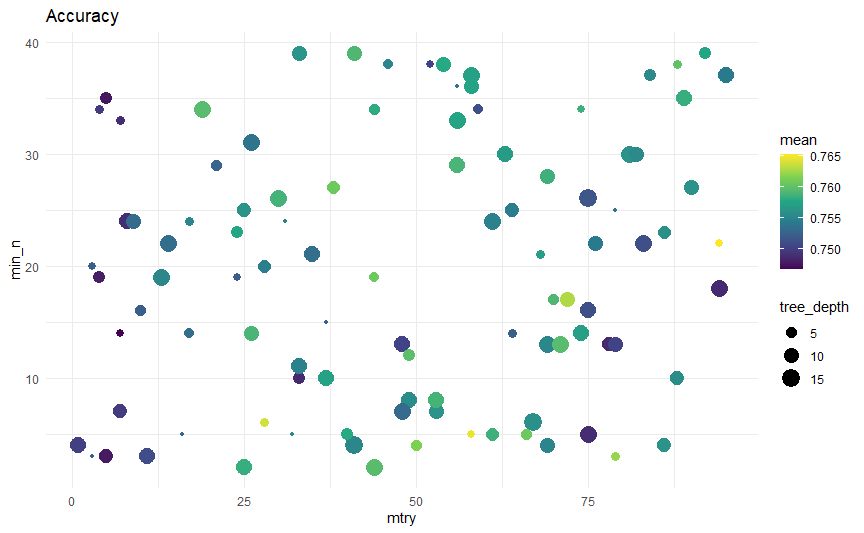

```r
xgboost_tuned %>%
  collect_metrics() %>%
  filter(.metric == "accuracy") %>%
  ggplot(aes(x = mtry, y = min_n, size = tree_depth, color = mean)) +
  geom_point() +
  scale_color_viridis_c() +
  labs(title = "Accuracy") +
  theme_minimal()
```

- `mtry`, `min_n` y `sample_size`:

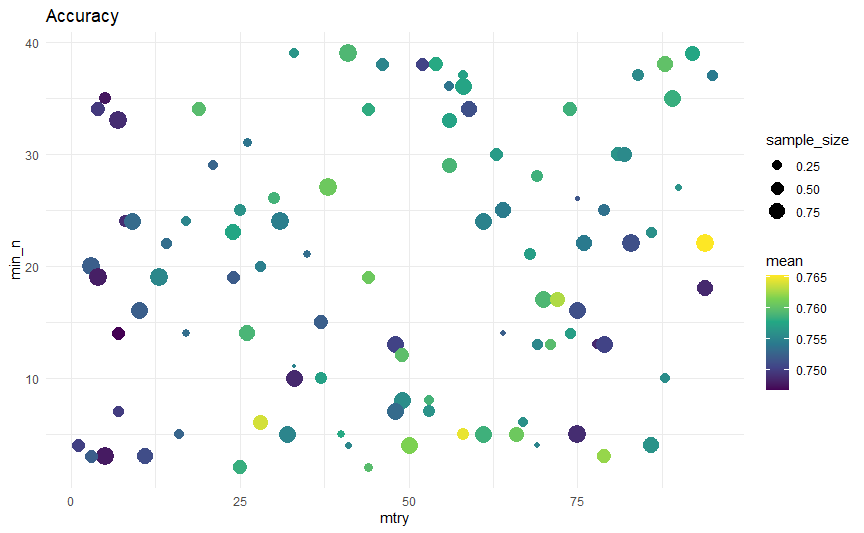

```r
xgboost_tuned %>%
  collect_metrics() %>%
  filter(.metric == "accuracy") %>%
  ggplot(aes(x = mtry, y = min_n, size = sample_size, color = mean)) +
  geom_point() +
  scale_color_viridis_c() +
  labs(title = "Accuracy") +
  theme_minimal()
```

- `mtry`, `min_n` y `loss_reduction`:

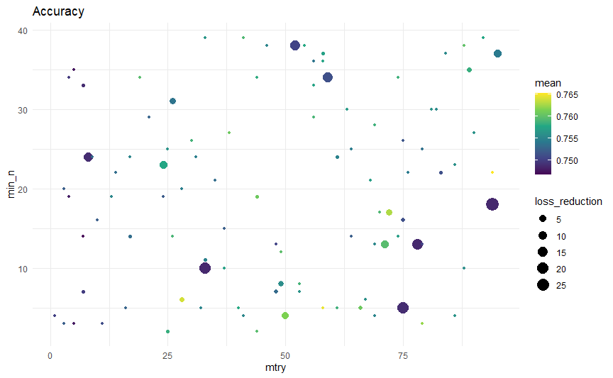

```r
xgboost_tuned %>%
  collect_metrics() %>%
  filter(.metric == "accuracy") %>%
  ggplot(aes(x = mtry, y = min_n, size = loss_reduction, color = mean)) +
  geom_point() +
  scale_color_viridis_c() +
  labs(title = "Accuracy") +
  theme_minimal()
```

### ROC-AUC

- **Hiperparámetros Individuales:**

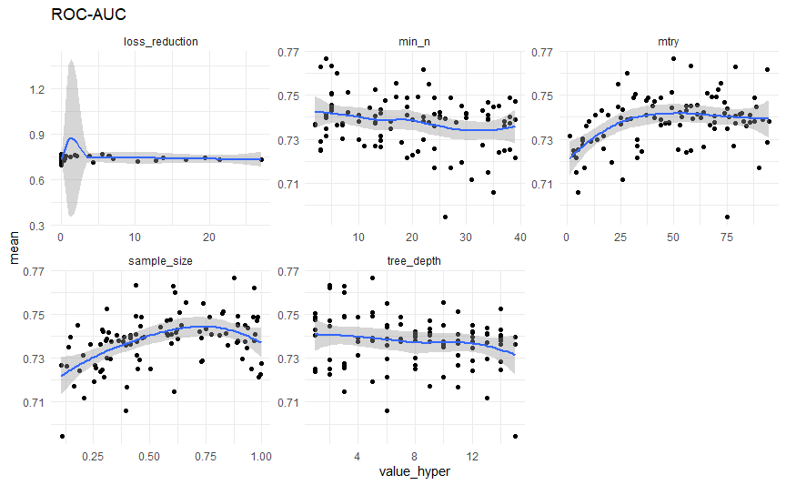

```r
xgboost_tuned %>%
  collect_metrics() %>%
  filter(.metric == "roc_auc") %>%
  select(mtry:sample_size, mean) %>%
  pivot_longer(cols = -mean, names_to = "hyperpar", values_to = "value_hyper") %>%
  ggplot(aes(x = value_hyper, y = mean)) +
  facet_wrap(~hyperpar, scales = "free") +
  geom_point() +
  geom_smooth(se = T) +
  labs(title = "ROC-AUC") +
  theme_minimal()
```

- `mtry`, `min_n` y `tree_depth`:

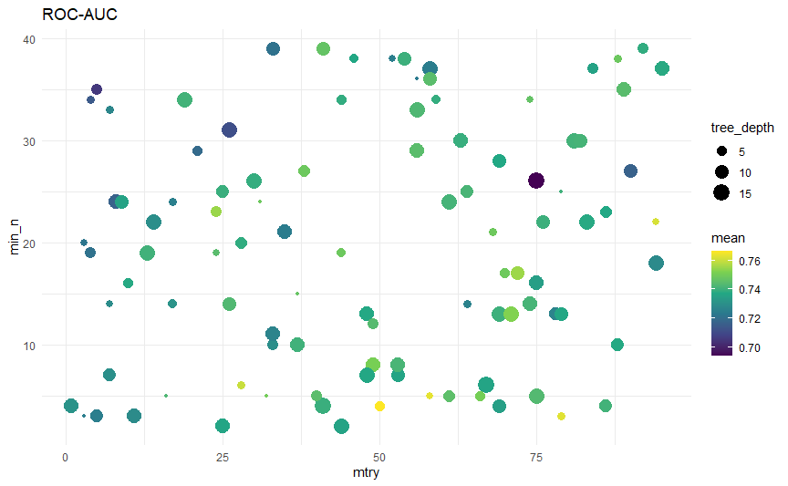

```r
xgboost_tuned %>%
  collect_metrics() %>%
  filter(.metric == "roc_auc") %>%
  ggplot(aes(x = mtry, y = min_n, size = tree_depth, color = mean)) +
  geom_point() +
  scale_color_viridis_c() +
  labs(title = "ROC-AUC") +
  theme_minimal()
```

- `mtry`, `min_n` y `sample_size`:

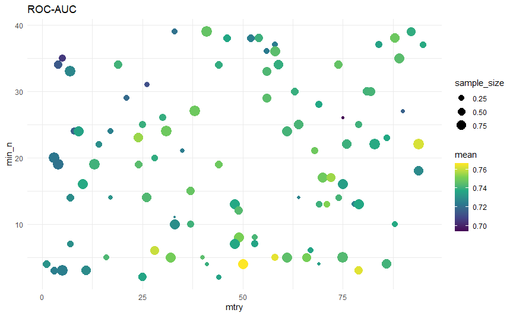

```r
xgboost_tuned %>%
  collect_metrics() %>%
  filter(.metric == "roc_auc") %>%
  ggplot(aes(x = mtry, y = min_n, size = sample_size, color = mean)) +
  geom_point() +
  scale_color_viridis_c() +
  labs(title = "ROC-AUC") +
  theme_minimal()
```

- `mtry`, `min_n` y `loss_reduction`:

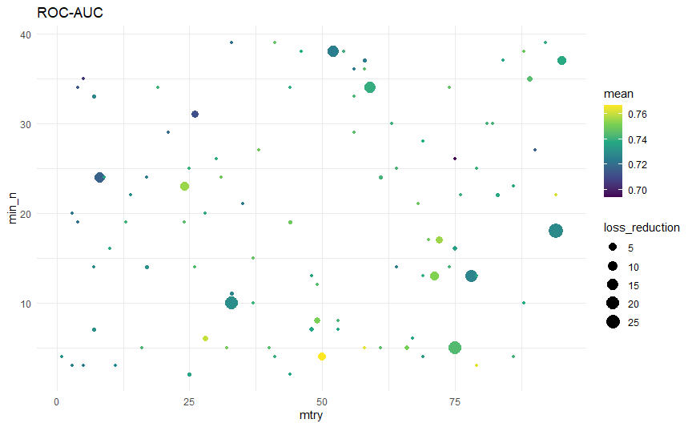

```r
xgboost_tuned %>%
  collect_metrics() %>%
  filter(.metric == "roc_auc") %>%
  ggplot(aes(x = mtry, y = min_n, size = loss_reduction, color = mean)) +
  geom_point() +
  scale_color_viridis_c() +
  labs(title = "ROC-AUC") +
  theme_minimal()
```

### F1 Score

- **Hiperparámetros Individuales:**

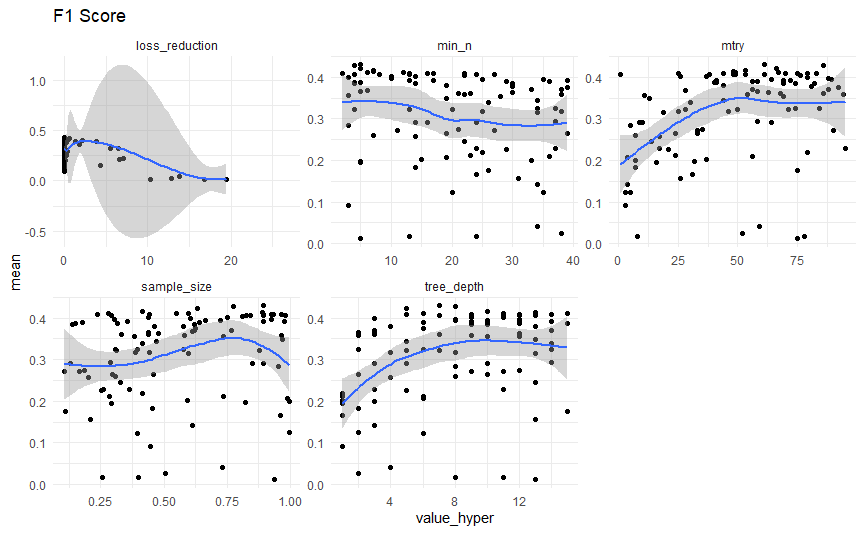

```r
xgboost_tuned %>%
  collect_metrics() %>%
  filter(.metric == "f_meas") %>%
  select(mtry:sample_size, mean) %>%
  pivot_longer(cols = -mean, names_to = "hyperpar", values_to = "value_hyper") %>%
  ggplot(aes(x = value_hyper, y = mean)) +
  facet_wrap(~hyperpar, scales = "free") +
  geom_point() +
  geom_smooth(se = T) +
  labs(title = "F1 Score") +
  theme_minimal()
```

- `mtry`, `min_n` y `tree_depth`:

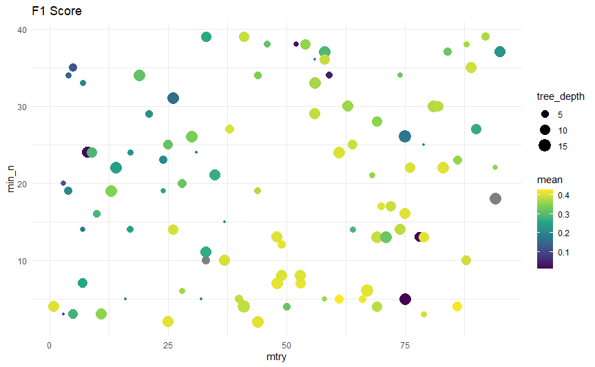

```r
xgboost_tuned %>%
  collect_metrics() %>%
  filter(.metric == "f_meas") %>%
  ggplot(aes(x = mtry, y = min_n, size = tree_depth, color = mean)) +
  geom_point() +
  scale_color_viridis_c() +
  labs(title = "F1 Score") +
  theme_minimal()
```

- `mtry`, `min_n` y `sample_size`:

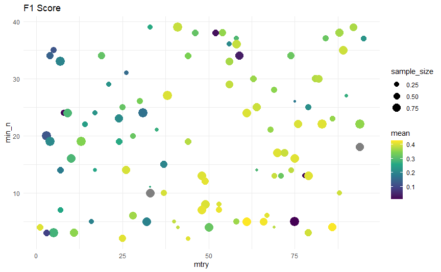

```r
xgboost_tuned %>%
  collect_metrics() %>%
  filter(.metric == "f_meas") %>%
  ggplot(aes(x = mtry, y = min_n, size = sample_size, color = mean)) +
  geom_point() +
  scale_color_viridis_c() +
  labs(title = "F1 Score") +
  theme_minimal()
```

- `mtry`, `min_n` y `loss_reduction`:

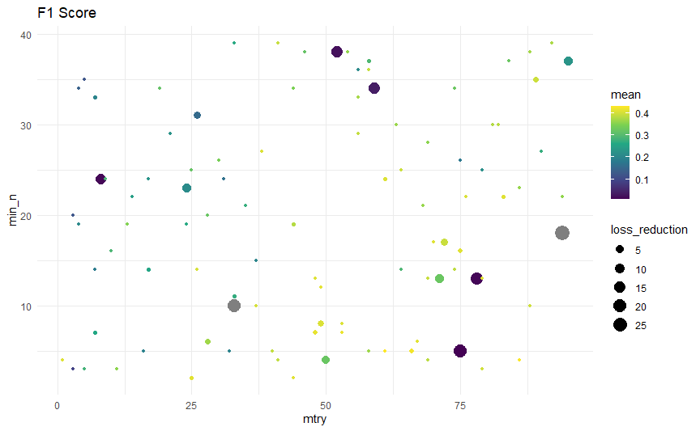

```r
xgboost_tuned %>%
  collect_metrics() %>%
  filter(.metric == "f_meas") %>%
  ggplot(aes(x = mtry, y = min_n, size = loss_reduction, color = mean)) +
  geom_point() +
  scale_color_viridis_c() +
  labs(title = "F1 Score") +
  theme_minimal()
```

## Modelo Final

### Accuracy

- El mejor modelo basado en la métrica *accuracy* es el siguiente:

```r
select_best(xgboost_tuned, metric = "accuracy")
```

| mtry | min_n | tree_depth | loss_reduction | sample_size | .config |
| --- | --- | --- | --- | --- | --- |
| 94 | 22 | 2 | 3.205681e-10 | 0.9643779 | Model066 |

- **Ajustando el modelo final basado en *accuracy*** :

```r
mejor_tuning_accuracy <-
  select_best(xgboost_tuned, metric = "accuracy")

modelo_final_accuracy <- finalize_workflow(xgboost_wf,
                                           parameters = mejor_tuning_accuracy)

doParallel::registerDoParallel()

ajuste_final_accuracy <- modelo_final_accuracy %>%
  fit(data_train_fin)

doParallel::stopImplicitCluster()
```

### ROC - AUC

- El mejor modelo basado en la métrica *ROC-AUC* es el siguiente:

```r
select_best(xgboost_tuned, metric = "roc_auc")
```

| mtry | min_n | tree_depth | loss_reduction | sample_size | .config |
| --- | --- | --- | --- | --- | --- |
| 50 | 4 | 5 | 5.557479 | 0.8778043 | Model001 |

- **Ajustando el modelo final basado en *ROC-AUC*** :

```r
mejor_tuning_roc_auc <-
  select_best(xgboost_tuned, metric = "roc_auc")

modelo_final_roc_auc <- finalize_workflow(xgboost_wf,
                                           parameters = mejor_tuning_roc_auc)

doParallel::registerDoParallel()

ajuste_final_roc_auc <- modelo_final_roc_auc %>%
  fit(data_train_fin)

doParallel::stopImplicitCluster()
```

### F1 Score

- El mejor modelo basado en la métrica *F1 Score* es el siguiente:

```r
select_best(xgboost_tuned, metric = "f_meas")
```

| mtry | min_n | tree_depth | loss_reduction | sample_size | .config |
| --- | --- | --- | --- | --- | --- |
| 61 | 5 | 7 | 8.797925e-05 | 0.8923916 | Model063 |

- **Ajustando el modelo final basado en *F1 Score*** :

```r
mejor_tuning_f1 <-
  select_best(xgboost_tuned, metric = "f_meas")

modelo_final_f1 <- finalize_workflow(xgboost_wf,
                                     parameters = mejor_tuning_f1)

doParallel::registerDoParallel()

ajuste_final_f1 <- modelo_final_f1 %>%
  fit(data_train_fin)

doParallel::stopImplicitCluster()
```

## Predicciones XGBoost Accuracy

### Train

- **Train:**

```r
predichos_train_accuracy <- ajuste_final_accuracy %>%
  predict(new_data = data_train_fin %>% select(-Rating), type = "class") %>%
  bind_cols(data_train_fin %>%  select(Rating)) %>%
  mutate_all(as.factor)
head(predichos_train_accuracy)
```

| .pred_class | Rating |
| --- | --- |
| 1 | 1 |
| 0 | 0 |
| 1 | 1 |
| 0 | 0 |
| 1 | 1 |
| 0 | 0 |

- **Matriz de confusión train:**

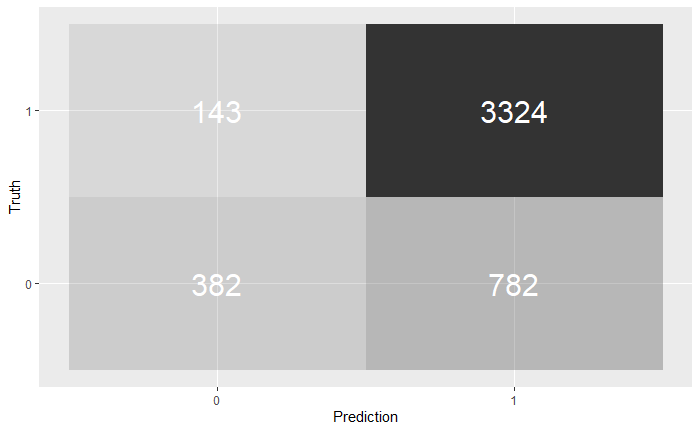

```r
predichos_train_accuracy %>%
  conf_mat(Rating, .pred_class) %>%
  pluck(1) %>%
  as_tibble() %>%
  ggplot(aes(x = Prediction, y = Truth, alpha = n)) +
  geom_tile(show.legend = FALSE) +
  geom_text(aes(label = n), colour = "white", alpha = 1, size = 8)
```

- **Precisión en train:**

```r
predichos_train_accuracy %>%
  metrics(Rating, .pred_class) %>%
  select(-.estimator) %>%
  filter(.metric == "accuracy")
```

| .metric | .estimate |
| --- | --- |
| accuracy | 0.8002591 |

- **F1 Score train:**

```r
predichos_train_accuracy %>%
  f_meas(Rating, .pred_class) %>%
  select(-.estimator)
```

| .metric | .estimate |
| --- | --- |
| f_meas | 0.4523387 |

### Validación

- **Validación:**

```r
# Receta en Test
test_baked  <- bake(object = receta1, new_data = data_test)

predichos_test <- ajuste_final_accuracy %>%
  predict(new_data = test_baked %>% select(-Rating), type = "class") %>%
  bind_cols(test_baked %>% select(Rating)) %>%
  mutate_all(as.factor)
head(predichos_test)
```

| .pred_class | Rating |
| --- | --- |
| 1 | 1 |
| 1 | 1 |
| 1 | 1 |
| 1 | 1 |
| 1 | 1 |
| 1 | 1 |

- **Matriz de confusión test:**

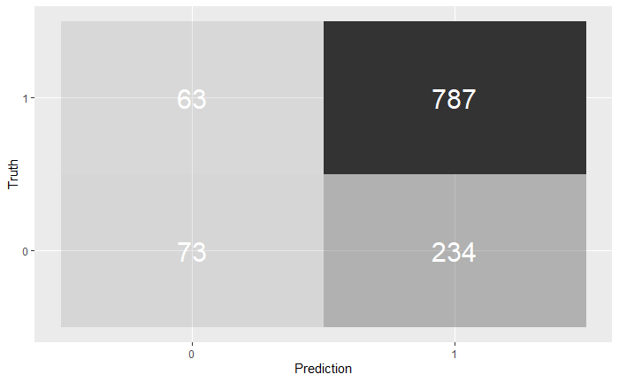

```r
predichos_test %>%
  conf_mat(Rating, .pred_class) %>%
  pluck(1) %>%
  as_tibble() %>%
  ggplot(aes(x = Prediction, y = Truth, alpha = n)) +
  geom_tile(show.legend = FALSE) +
  geom_text(aes(label = n), colour = "white", alpha = 1, size = 8)
```

- **Precisión en validación:**

```r
predichos_test %>%
  metrics(Rating, .pred_class) %>%
  select(-.estimator) %>%
  filter(.metric == "accuracy")
```

| .metric | .estimate |
| --- | --- |
| accuracy | 0.7433016 |

- **F1 Score validación:**

```r
predichos_test %>%
  f_meas(Rating, .pred_class) %>%
  select(-.estimator)
```

| .metric | .estimate |
| --- | --- |
| f_meas | 0.3295711 |

### Submission

- **Modelo con todos los datos:**

```r
new_train <- bake(object = receta1, new_data = binar_train)

doParallel::registerDoParallel()

ultimo_ajuste_accuracy <- modelo_final_accuracy %>%
  fit(new_train)

doParallel::stopImplicitCluster()
```

- **Predicciones finales:**

```r
predichos_final1 <- ultimo_ajuste_accuracy %>%
  predict(new_data = binar_test, type = "class")

# Submission
sampleSub %>%
  select(-rating) %>%
  mutate(rating = predichos_final1$.pred_class) ->
  sub_07_xgboost
head(sub_07_xgboost)
```

| id | rating |
| --- | --- |
| 5788 | 1 |
| 5789 | 1 |
| 5790 | 1 |
| 5791 | 1 |
| 5792 | 1 |
| 5793 | 0 |

- **Exportando predicciones:**

```r
write_csv(sub_07_xgboost, file = "../submission/sub_07_xgboost.csv")
```

## Predicciones XGBoost ROC-AUC

### Train

- **Train:**

```r
predichos_train_roc <- ajuste_final_roc_auc %>%
  predict(new_data = data_train_fin %>% select(-Rating), type = "class") %>%
  bind_cols(data_train_fin %>%  select(Rating)) %>%
  mutate_all(as.factor)
head(predichos_train_roc)
```

| .pred_class | Rating |
| --- | --- |
| 1 | 1 |
| 0 | 0 |
| 1 | 1 |
| 0 | 0 |
| 1 | 1 |
| 0 | 0 |

- **Matriz de confusión train:**

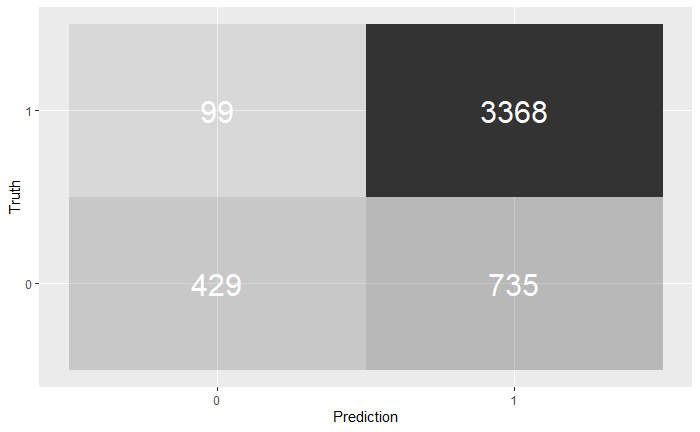

```r
predichos_train_roc %>%
  conf_mat(Rating, .pred_class) %>%
  pluck(1) %>%
  as_tibble() %>%
  ggplot(aes(x = Prediction, y = Truth, alpha = n)) +
  geom_tile(show.legend = FALSE) +
  geom_text(aes(label = n), colour = "white", alpha = 1, size = 8)
```

- **Precisión en train:**

```r
predichos_train_roc %>%
  metrics(Rating, .pred_class) %>%
  select(-.estimator) %>%
  filter(.metric == "accuracy")
```

| .metric | .estimate |
| --- | --- |
| accuracy | 0.8199093 |

- **F1 Score train:**

```r
predichos_train_roc %>%
  f_meas(Rating, .pred_class) %>%
  select(-.estimator)
```

| .metric | .estimate |
| --- | --- |
| f_meas | 0.5070922 |

### Validación

- **Validación:**

```r
predichos_test_roc <- ajuste_final_roc_auc %>%
  predict(new_data = test_baked %>% select(-Rating), type = "class") %>%
  bind_cols(test_baked %>% select(Rating)) %>%
  mutate_all(as.factor)
head(predichos_test_roc )
```

| .pred_class | Rating |
| --- | --- |
| 1 | 1 |
| 1 | 1 |
| 1 | 1 |
| 1 | 1 |
| 1 | 1 |
| 1 | 1 |

- **Matriz de confusión test:**

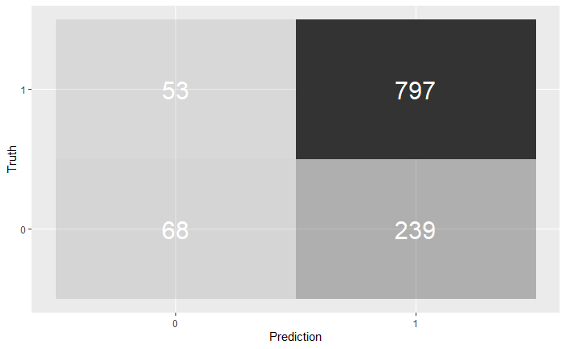

```r
predichos_test_roc %>%
  conf_mat(Rating, .pred_class) %>%
  pluck(1) %>%
  as_tibble() %>%
  ggplot(aes(x = Prediction, y = Truth, alpha = n)) +
  geom_tile(show.legend = FALSE) +
  geom_text(aes(label = n), colour = "white", alpha = 1, size = 8)
```

- **Precisión en validación:**

```r
predichos_test_roc %>%
  metrics(Rating, .pred_class) %>%
  select(-.estimator) %>%
  filter(.metric == "accuracy")
```

| .metric | .estimate |
| --- | --- |
| accuracy | 0.7476232 |

- **F1 Score validación:**

```r
predichos_test_roc %>%
  f_meas(Rating, .pred_class) %>%
  select(-.estimator)
```

| .metric | .estimate |
| --- | --- |
| f_meas | 0.317757 |

### Submission

- **Modelo con todos los datos:**

```r
doParallel::registerDoParallel()

ultimo_ajuste_roc <- modelo_final_roc_auc %>%
  fit(new_train)

doParallel::stopImplicitCluster()
```

- **Predicciones finales:**

```r
predichos_final2 <- ultimo_ajuste_roc %>%
  predict(new_data = binar_test, type = "class")

# Submission
sampleSub %>%
  select(-rating) %>%
  mutate(rating = predichos_final2$.pred_class) ->
  sub_08_xgboost
head(sub_08_xgboost)
```

| id | rating |
| --- | --- |
| 5788 | 1 |
| 5789 | 1 |
| 5790 | 1 |
| 5791 | 1 |
| 5792 | 1 |
| 5793 | 0 |

- **Exportando predicciones:**

```r
write_csv(sub_08_xgboost, file = "../submission/sub_08_xgboost.csv")
```

## Predicciones XGBoost F1 Score

### Train

- **Train:**

```r
predichos_train_f1 <- ajuste_final_f1 %>%
  predict(new_data = data_train_fin %>% select(-Rating), type = "class") %>%
  bind_cols(data_train_fin %>%  select(Rating)) %>%
  mutate_all(as.factor)
head(predichos_train_f1)
```

| .pred_class | Rating |
| --- | --- |
| 1 | 1 |
| 0 | 0 |
| 1 | 1 |
| 0 | 0 |
| 1 | 1 |
| 0 | 0 |

- **Matriz de confusión train:**

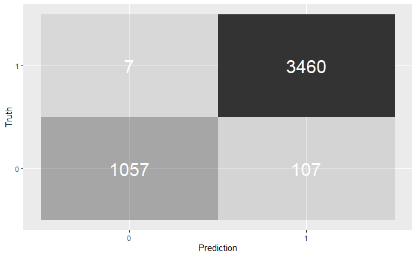

```r
predichos_train_f1 %>%
  conf_mat(Rating, .pred_class) %>%
  pluck(1) %>%
  as_tibble() %>%
  ggplot(aes(x = Prediction, y = Truth, alpha = n)) +
  geom_tile(show.legend = FALSE) +
  geom_text(aes(label = n), colour = "white", alpha = 1, size = 8)
```

- **Precisión en train:**

```r
predichos_train_f1 %>%
  metrics(Rating, .pred_class) %>%
  select(-.estimator) %>%
  filter(.metric == "accuracy")
```

| .metric | .estimate |
| --- | --- |
| accuracy | 0.9753833 |

- **F1 Score train:**

```r
predichos_train_f1 %>%
  f_meas(Rating, .pred_class) %>%
  select(-.estimator)
```

| .metric | .estimate |
| --- | --- |
| f_meas | 0.948833 |

### Validación

- **Validación:**

```r
predichos_test_f1 <- ajuste_final_f1 %>%
  predict(new_data = test_baked %>% select(-Rating), type = "class") %>%
  bind_cols(test_baked %>% select(Rating)) %>%
  mutate_all(as.factor)
head(predichos_test_f1)
```

| .pred_class | Rating |
| --- | --- |
| 1 | 1 |
| 1 | 1 |
| 1 | 1 |
| 1 | 1 |
| 1 | 1 |
| 1 | 1 |

- **Matriz de confusión test:**

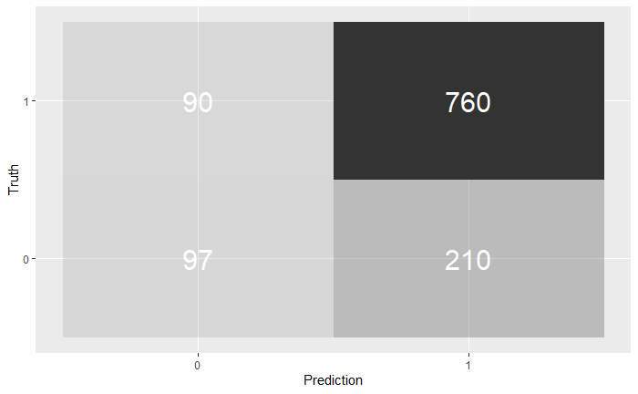

```r
predichos_test_f1 %>%
  conf_mat(Rating, .pred_class) %>%
  pluck(1) %>%
  as_tibble() %>%
  ggplot(aes(x = Prediction, y = Truth, alpha = n)) +
  geom_tile(show.legend = FALSE) +
  geom_text(aes(label = n), colour = "white", alpha = 1, size = 8)
```

- **Precisión en validación:**

```r
predichos_test_f1 %>%
  metrics(Rating, .pred_class) %>%
  select(-.estimator) %>%
  filter(.metric == "accuracy")
```

| .metric | .estimate |
| --- | --- |
| accuracy | 0.7407087 |

- **F1 Score validación:**

```r
predichos_test_f1 %>%
  f_meas(Rating, .pred_class) %>%
  select(-.estimator)
```

| .metric | .estimate |
| --- | --- |
| f_meas | 0.3927126 |

### Submission

- **Modelo con todos los datos:**

```r
doParallel::registerDoParallel()

ultimo_ajuste_f1 <- modelo_final_f1 %>%
  fit(new_train)

doParallel::stopImplicitCluster()
```

- **Predicciones finales:**

```r
predichos_final3 <- ultimo_ajuste_f1 %>%
  predict(new_data = binar_test, type = "class")

# Submission
sampleSub %>%
  select(-rating) %>%
  mutate(rating = predichos_final3$.pred_class) ->
  sub_09_xgboost
head(sub_09_xgboost)
```

| id | rating |
| --- | --- |
| 5788 | 1 |
| 5789 | 1 |
| 5790 | 0 |
| 5791 | 1 |
| 5792 | 1 |
| 5793 | 0 |

- **Exportando predicciones:**

```r
write_csv(sub_09_xgboost, file = "../submission/sub_09_xgboost.csv")
```